# PCA

2020-04-20

Es de reconocer que soy un gran fanático del trabajo de [Julia Silge](https://juliasilge.com/), quien hace poco empezo a trabajar como software engineer en R Studio. Su comprensión de la estadística es profundo y su capacidad de desarrollo de esta herramienta y generar una experiencia en `tidymodels` es de sobrada admiración.

En su nuevo post sobre la aplicación del **Principal Component Analysis** sobre canciones de Hip Hop vía `recipes` es un caso de estudio el cual abordaré de manera desagregada.

## ¿ En qué consiste los PCAs?

Una definición muy acertada que alberga [wikipedia](https://es.wikipedia.org/wiki/An%C3%A1lisis_de_componentes_principales) es la siguiente :

> “Es una técnica utilizada para describir un conjunto de datos en términos de nuevas variables no correlacionadas”

Esto llevado al plano de Machine Learning tiene un gran potencial. Lo importante en esta técnica es la capacidad que tiene para reducir la dimensionalidad de los datos.

Otra definición que vale la pena rescatar es dada por [Joaquín Amat](https://www.cienciadedatos.net/documentos/35_principal_component_analysis), en donde la describe de la siguiente manera:

> “Es un método estadístico que permite simplificar la complejidad de las variables de los espacios muestrales, a través de muchas dimensiones que conservan la información”

La información en estos términos debe leerse como: Varianza. Dicho de otro modo Los PCAs son dichas técnicas que logran simplificar los set de datos vía un número menor de features en un número optimo de componentes.

### Componentes de los PCAs.

- Eigenvector: Una forma simple de entender los vectores propios es la de dotadores de dirección
- Eigenvalue: los valores propios es la que indica cuanta varianza hay en los datos del eigenvector.

### una aproximación del PCA

Un ejemplo simple para entender esta técnica es la siguiente, se usará la base de datos `mtcars` que viene por defecto en R.

Se seleccionaran nueve variables para este proceso y se usará la función prcomp, la cual dada una matriz, retorna los resultados como objetos de los componentes.

```r
cars_PCA<-prcomp(mtcars[,c(1:7,10,11)], center = TRUE,scale. = TRUE)
cars_PCA%>%
  summary()
```

```
## Importance of components:
##                           PC1    PC2     PC3     PC4     PC5     PC6     PC7
## Standard deviation     2.3782 1.4429 0.71008 0.51481 0.42797 0.35184 0.32413
## Proportion of Variance 0.6284 0.2313 0.05602 0.02945 0.02035 0.01375 0.01167
## Cumulative Proportion  0.6284 0.8598 0.91581 0.94525 0.96560 0.97936 0.99103
##                           PC8     PC9
## Standard deviation     0.2419 0.14896
## Proportion of Variance 0.0065 0.00247
## Cumulative Proportion  0.9975 1.00000
```

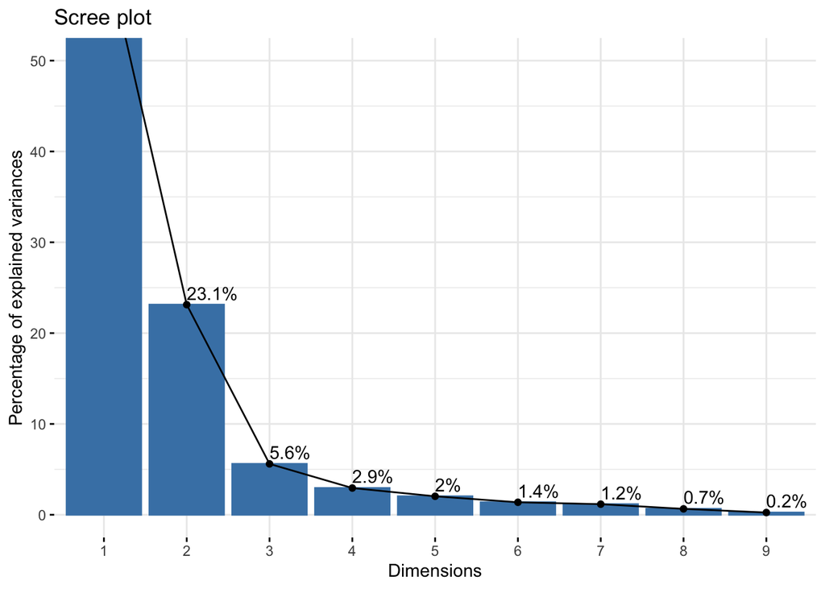

Y validando geométricamente como es el comportamiento de las variables, se observa lo siguiente.

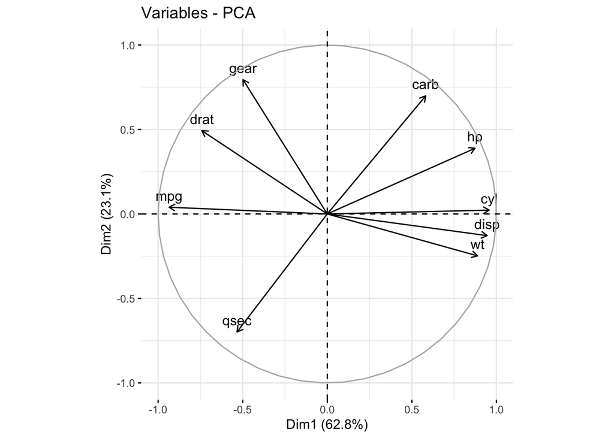

Todo lo que está sobre el coseno debe leerse como una variable explicativa que almacena gran porpiedad y valor y que por ende puede explicar las variables que se encuentran en contraposición (ejes opuestos).

Sustentando el PCA es de notar que sobre el coseno $x$ hay tres variables, lo cual es de gran refuerzo para los pasos a seguir.

Una forma de mejorar la interpretación de este PCA es a través de la caracterización de los carros

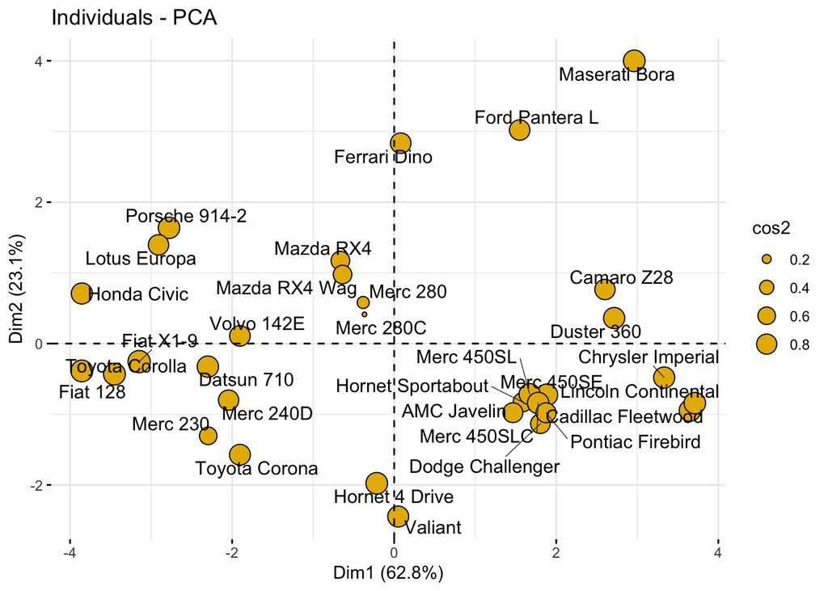

En este caso los gradientes muestran la capacidad de correlaciones y por ende de explicaciones sobre los carros dada la marca.

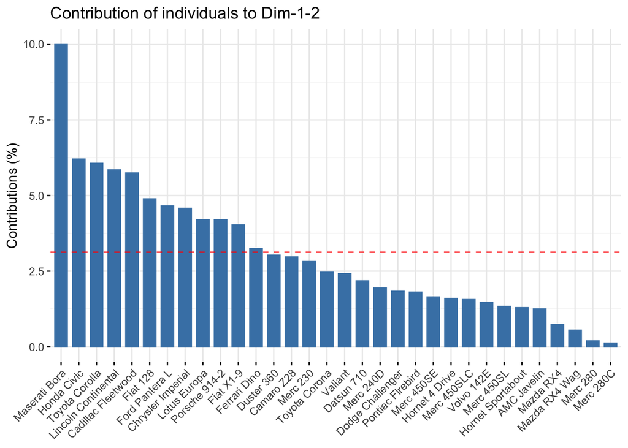

Si se trabajase un feature el resultado sería más valioso. En esta parte tomo el ejemplo usado en Datacamp, puesto que su nivel de interpretación es invaluable.

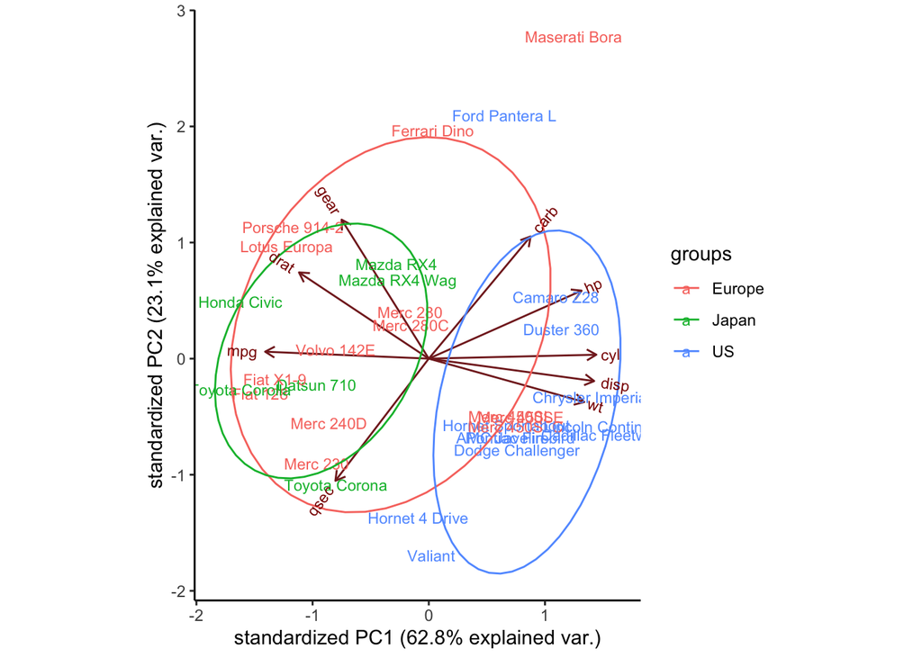

Se puede apreciar que los carros de origen americano tienen como caracteristícas de altos valores en en cylinders, Displacement y en Weight.

Para verlo de una marena más amena se trabajaría con la siguiente gráfica (sustentar respuesta anterior)

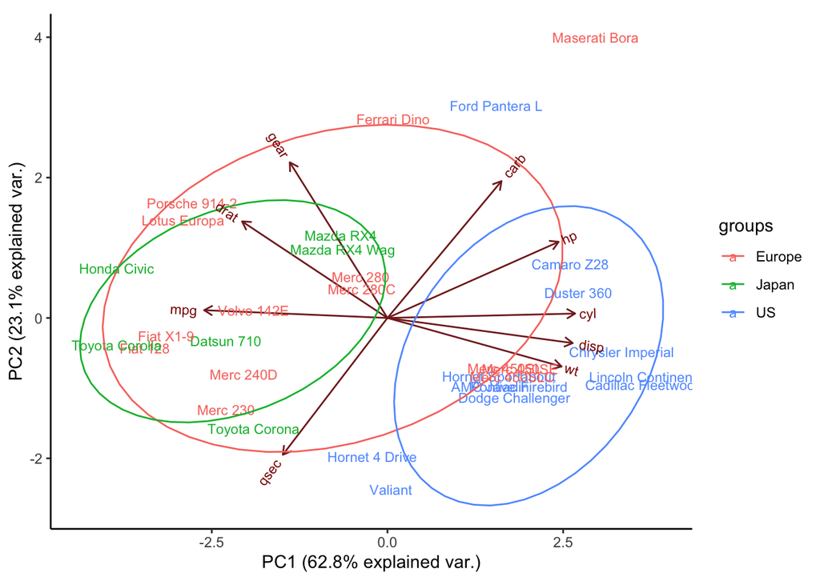

### Ranking de las canciones

El objetivo de este modelo es comprender cuales son las canciones mejor valoradas por los críticos.

Se desarrolla un análisis corto de los datos

```
## Rows: 311
## Columns: 12
## $ ID     <dbl> 1, 2, 3, 4, 5, 6, 7, 8, 9, 10, 11, 12, 13, 14, 15, 16, 17, 18,…
## $ title  <chr> "Juicy", "Fight The Power", "Shook Ones (Part II)", "The Messa…
## $ artist <chr> "The Notorious B.I.G.", "Public Enemy", "Mobb Deep", "Grandmas…
## $ year   <dbl> 1994, 1989, 1995, 1982, 1992, 1993, 1993, 1992, 1994, 1995, 20…
## $ gender <chr> "male", "male", "male", "male", "male", "male", "male", "male"…
## $ points <dbl> 140, 100, 94, 90, 84, 62, 50, 48, 46, 42, 38, 36, 36, 34, 32, …
## $ n      <dbl> 18, 11, 13, 14, 14, 10, 7, 6, 7, 6, 5, 5, 4, 6, 5, 5, 4, 5, 5,…
## $ n1     <dbl> 9, 7, 4, 5, 2, 3, 2, 3, 1, 2, 2, 1, 2, 1, 1, 0, 2, 2, 1, 1, 1,…
## $ n2     <dbl> 3, 3, 5, 3, 4, 1, 2, 2, 3, 1, 0, 1, 2, 0, 1, 3, 1, 0, 1, 1, 1,…
## $ n3     <dbl> 3, 1, 1, 1, 2, 1, 2, 0, 1, 1, 3, 3, 0, 2, 2, 1, 0, 1, 1, 1, 0,…
## $ n4     <dbl> 1, 0, 1, 0, 4, 4, 0, 0, 1, 2, 0, 0, 0, 3, 0, 0, 1, 0, 1, 0, 2,…
## $ n5     <dbl> 2, 0, 2, 5, 2, 1, 1, 1, 1, 0, 0, 0, 0, 0, 1, 1, 0, 2, 1, 2, 1,…
```

Hay una variable interesante sobre el set de datos y es el genero. Pero antes de desarrollar un análisis sobre ello trabajaré en dos fases de interpretación. Con `skim` describire rapidamente el comportamiento y la estructura de los datos

Data summary

| Name | rankings |
| --- | --- |
| Number of rows | 311 |
| Number of columns | 12 |
| _______________________ |  |
| Column type frequency: |  |
| character | 3 |
| numeric | 9 |
| ________________________ |  |
| Group variables | None |

**Variable type: character**

| skim_variable | n_missing | complete_rate | min | max | empty | n_unique | whitespace |
| --- | --- | --- | --- | --- | --- | --- | --- |
| title | 0 | 1 | 2 | 59 | 0 | 309 | 0 |
| artist | 0 | 1 | 3 | 56 | 0 | 207 | 0 |
| gender | 0 | 1 | 4 | 6 | 0 | 3 | 0 |

**Variable type: numeric**

| skim_variable | n_missing | complete_rate | mean | sd | p0 | p25 | p50 | p75 | p100 | hist |
| --- | --- | --- | --- | --- | --- | --- | --- | --- | --- | --- |
| ID | 0 | 1 | 156.00 | 89.92 | 1 | 78.5 | 156 | 233.5 | 311 | ▇▇▇▇▇ |
| year | 0 | 1 | 2000.41 | 9.20 | 1979 | 1994.0 | 1999 | 2007.0 | 2019 | ▂▆▇▃▅ |
| points | 0 | 1 | 10.32 | 14.64 | 2 | 4.0 | 6 | 10.0 | 140 | ▇▁▁▁▁ |
| n | 0 | 1 | 1.72 | 2.01 | 1 | 1.0 | 1 | 2.0 | 18 | ▇▁▁▁▁ |
| n1 | 0 | 1 | 0.34 | 0.89 | 0 | 0.0 | 0 | 0.0 | 9 | ▇▁▁▁▁ |
| n2 | 0 | 1 | 0.34 | 0.69 | 0 | 0.0 | 0 | 1.0 | 5 | ▇▁▁▁▁ |
| n3 | 0 | 1 | 0.34 | 0.59 | 0 | 0.0 | 0 | 1.0 | 3 | ▇▃▁▁▁ |
| n4 | 0 | 1 | 0.34 | 0.62 | 0 | 0.0 | 0 | 1.0 | 4 | ▇▃▁▁▁ |
| n5 | 0 | 1 | 0.34 | 0.60 | 0 | 0.0 | 0 | 1.0 | 5 | ▇▁▁▁▁ |

Me llama la atención el comportamiento de n3 y n4. Los n`s significan los votos #3 y #4.

Exploraré la correlación de las variables cuantitativas.

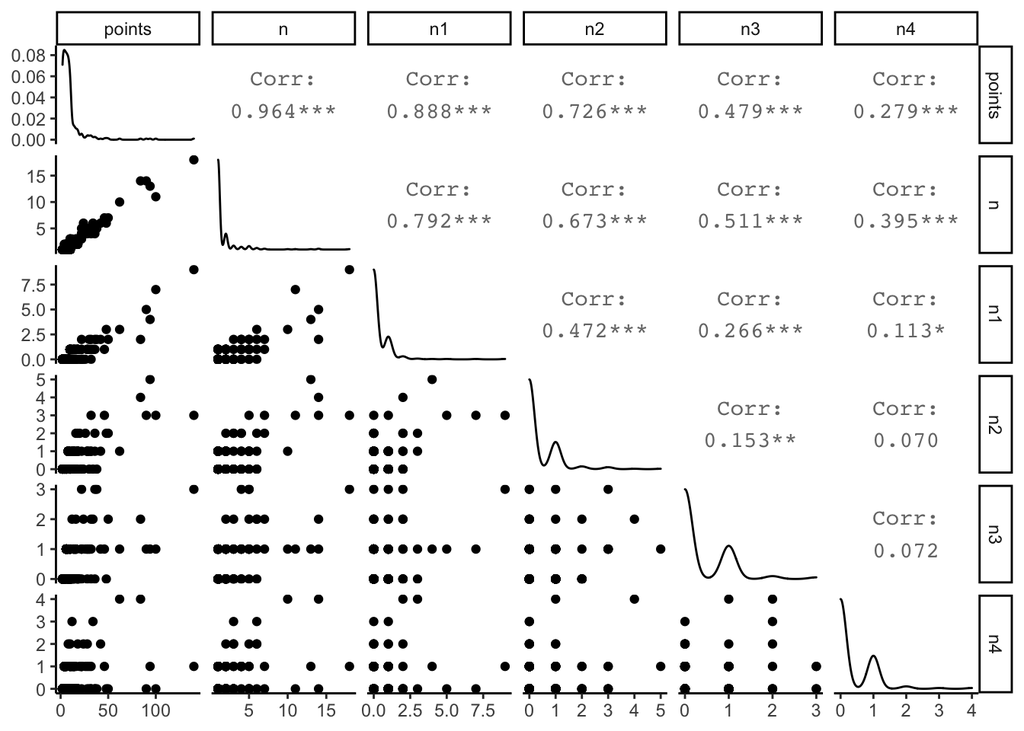

Hay correlaciones lineales importantes entre los `points` y el número de votaciones, lo importante a destacar es que se disipan conforme aumenta el número de n. Este será un caso interesante para trabajar con redes neuronales.

Una inquietud sobre estas relaciones va atada al genero, ¿cómo será su comportamiento?

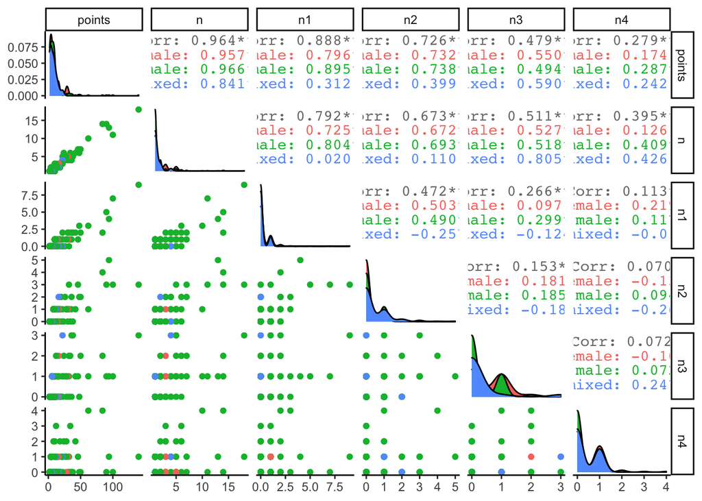

Este tipo de correlación da un gran insigth sobre el camino a abordar para desarrollar un modelo.

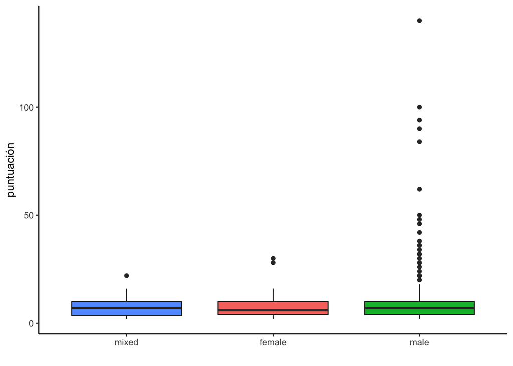

La presencia de outliers es bastante alta en el caso de los hombres. Será mejor valorar este comportamiento por decadas

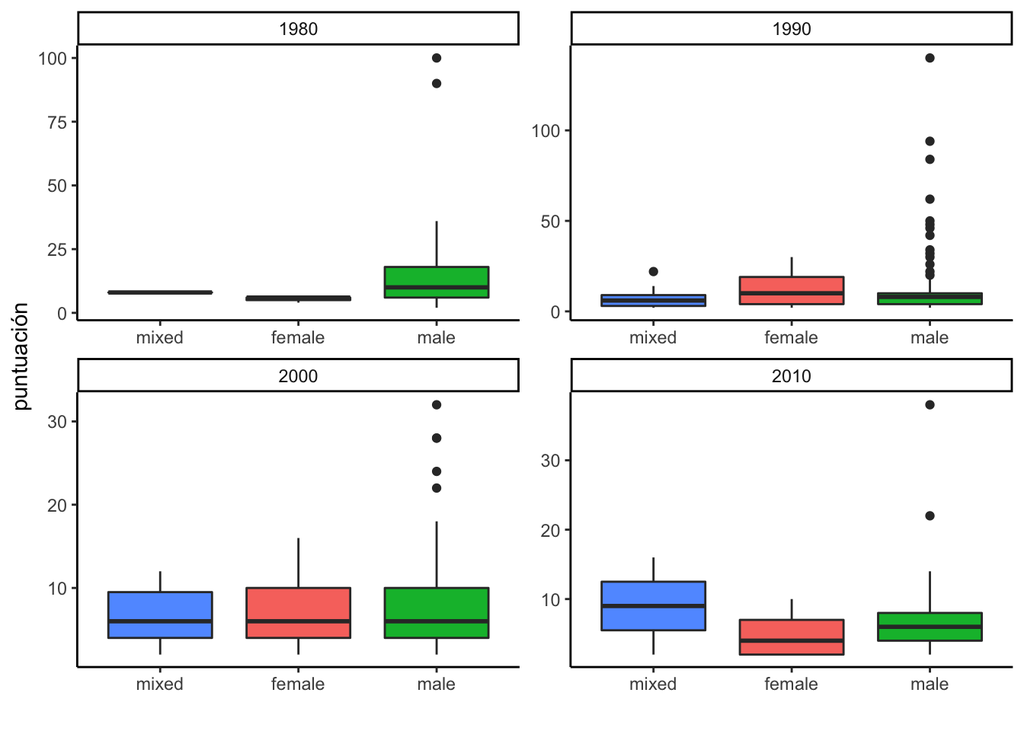

```r
rankings%>%
  filter(decade!=1970)%>%
  ggplot(aes(reorder(gender,points),points, fill=gender))+
  geom_boxplot()+
  guides(fill=FALSE)+
  labs(x="",
       y="puntuación")+
  facet_wrap(~decade, scales = 'free')
```

Más curioso termino siendo el análsis por decada, parece ser que en efecto son outliers, más no anomalías. Pero para avanzar en este análisis primerio es mejor ordenar este gráfico.

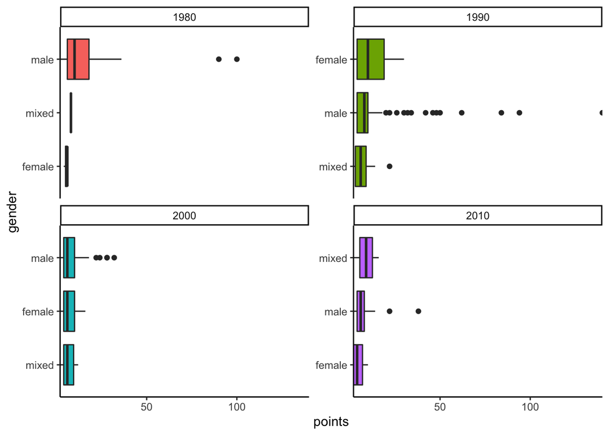

Hay una clara relación entre la decada, la puntuación y los generos, esto debe explorarse más a fondo, pero en está oportunidad no será.

Ahora trabajaré un modelo de regresión para entender que generos son los más escuchados.

```r
ind<-initial_split(rankings[,-c(1:3)],strata = gender)
training_data<-training(ind)
testing_data<-testing(ind)
training_data%>%
  lm(log(points)~.,data=.)->ranking_lm

ranking_lm%>%
  summary()
```

```
##
## Call:
## lm(formula = log(points) ~ ., data = .)
##
## Residuals:
##      Min       1Q   Median       3Q      Max
## -1.90617 -0.31830 -0.02374  0.28233  1.40014
##
## Coefficients: (1 not defined because of singularities)
##              Estimate Std. Error t value Pr(>|t|)
## (Intercept) 20.510355   6.524585   3.144  0.00189 **
## year        -0.021768   0.011243  -1.936  0.05412 .
## gendermale  -0.008226   0.104538  -0.079  0.93735
## gendermixed -0.057977   0.146642  -0.395  0.69295
## n           -0.387033   0.054281  -7.130 1.37e-11 ***
## n1           0.723963   0.071682  10.100  < 2e-16 ***
## n2           0.873544   0.072966  11.972  < 2e-16 ***
## n3           0.837762   0.073176  11.449  < 2e-16 ***
## n4           0.557821   0.068758   8.113 3.25e-14 ***
## n5                 NA         NA      NA       NA
## decade       0.012317   0.010829   1.137  0.25661
## ---
## Signif. codes:  0 '***' 0.001 '**' 0.01 '*' 0.05 '.' 0.1 ' ' 1
##
## Residual standard error: 0.4403 on 224 degrees of freedom
## Multiple R-squared:  0.7483, Adjusted R-squared:  0.7381
## F-statistic: 73.98 on 9 and 224 DF,  p-value: < 2.2e-16
```

```r
modelo <- lm(log(points) ~ ., data = training_data)
summary(modelo)
```

```
##
## Call:
## lm(formula = log(points) ~ ., data = training_data)
##
## Residuals:
##      Min       1Q   Median       3Q      Max
## -1.90617 -0.31830 -0.02374  0.28233  1.40014
##
## Coefficients: (1 not defined because of singularities)
##              Estimate Std. Error t value Pr(>|t|)
## (Intercept) 20.510355   6.524585   3.144  0.00189 **
## year        -0.021768   0.011243  -1.936  0.05412 .
## gendermale  -0.008226   0.104538  -0.079  0.93735
## gendermixed -0.057977   0.146642  -0.395  0.69295
## n           -0.387033   0.054281  -7.130 1.37e-11 ***
## n1           0.723963   0.071682  10.100  < 2e-16 ***
## n2           0.873544   0.072966  11.972  < 2e-16 ***
## n3           0.837762   0.073176  11.449  < 2e-16 ***
## n4           0.557821   0.068758   8.113 3.25e-14 ***
## n5                 NA         NA      NA       NA
## decade       0.012317   0.010829   1.137  0.25661
## ---
## Signif. codes:  0 '***' 0.001 '**' 0.01 '*' 0.05 '.' 0.1 ' ' 1
##
## Residual standard error: 0.4403 on 224 degrees of freedom
## Multiple R-squared:  0.7483, Adjusted R-squared:  0.7381
## F-statistic: 73.98 on 9 and 224 DF,  p-value: < 2.2e-16
```

Al revisar el MSE, el resultado es el siguiente

```r
training_mse <- mean((modelo$fitted.values - log(training_data$points))^2)
training_mse
```

```
## [1] 0.1855756
```

```r
predicciones <- predict(modelo, newdata = testing_data)
test_mse <- mean((predicciones - log(testing_data$points))^2)
test_mse
```

```
## [1] 0.1903351
```

Ahora la regresión con el PCA

```r
pca_ranking<-prcomp(training_data[,-c(1:4)],scale. = TRUE)
pca_ranking%>%
  summary()
```

```
## Importance of components:
##                          PC1    PC2    PC3    PC4    PC5     PC6
## Standard deviation     1.370 1.0198 0.9751 0.9433 0.8801 0.68330
## Proportion of Variance 0.313 0.1733 0.1585 0.1483 0.1291 0.07782
## Cumulative Proportion  0.313 0.4863 0.6448 0.7931 0.9222 1.00000
```

Entender que hasta el PC5 hay alta alacenamiento de la información es necesario desarrollar un gráfico más

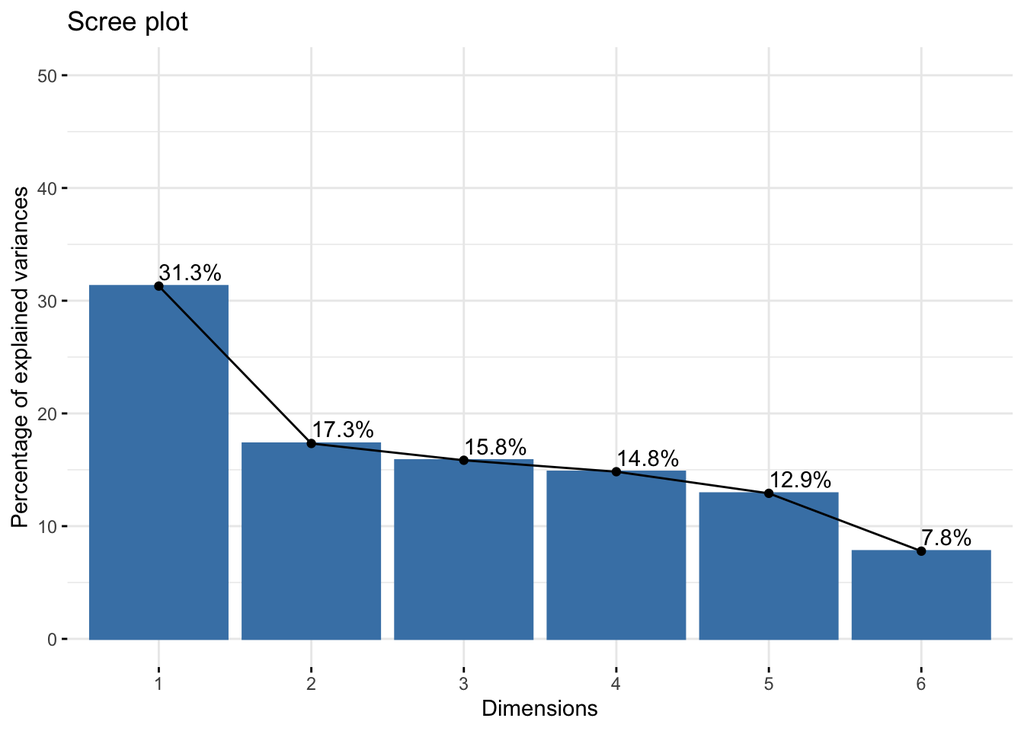

```r
fviz_eig(pca_ranking, addlabels = TRUE, ylim = c(0, 50))
```

A este modelo le falta un mayor desgloce

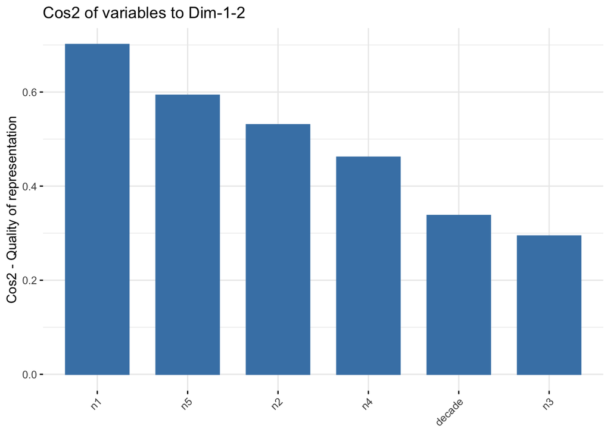

```r
fviz_cos2(pca_ranking, choice = "var", axes = 1:2)
```

En estas relaciones hace falta mayor detalle para poder trabajar de manera oportuna, más da una buena aproximación al siguiente trabajo

```r
library( neuralnet )
```

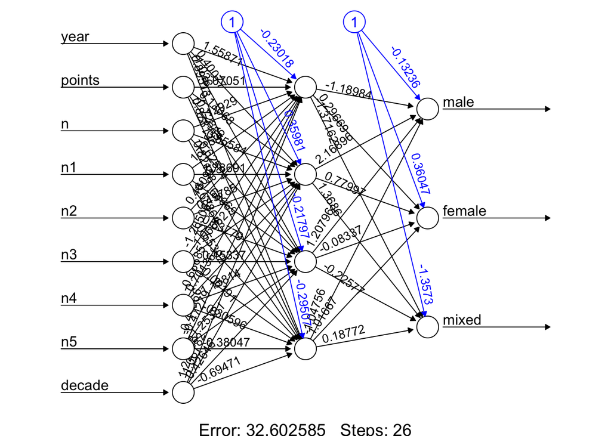

```r
n = names( training_data )
f = as.formula( paste( "gender ~", paste( n[!n %in% "gender"], collapse = "+" ) ) )
nn = neuralnet( f, training_data, hidden = 4, linear.output = FALSE, threshold = 0.01 )

plot( nn, rep = "best" )
```

Ahora con el PCA

```r
pca$x
```

[output not shown]

[output cut: 455 more lines]

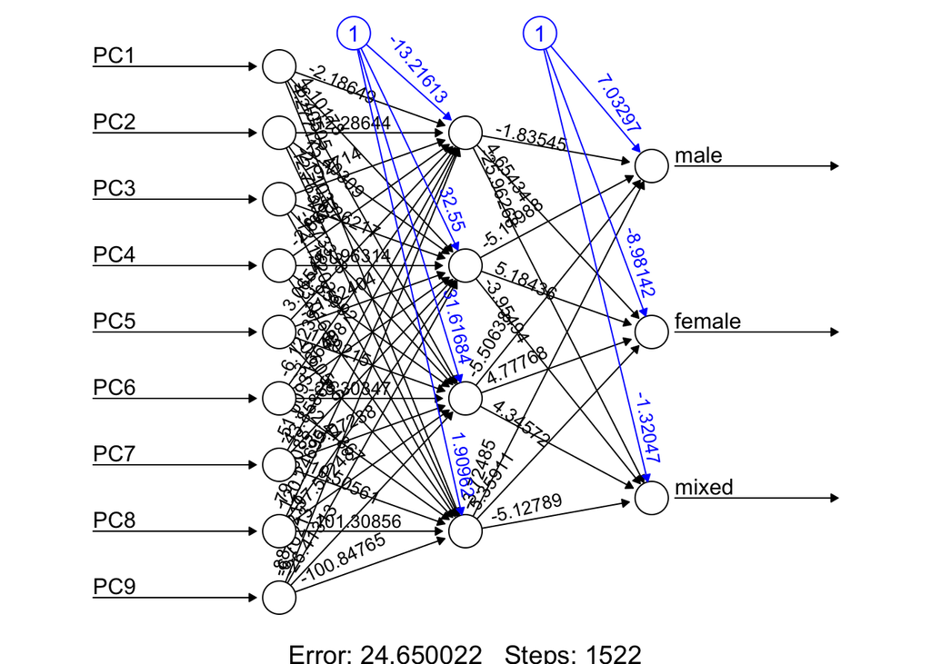

```r
train = data.frame(gender = training_data$gender, pca$x)
t = as.data.frame( predict( pca, newdata = pca_testset ) )

new_trainset = train[, c(1,2,3,4:10)]
new_testset =  t[, , c(1,3,4:10)]



n = names( new_trainset )
f = as.formula( paste( "gender ~", paste( n[!n %in% "gender" ], collapse = "+" ) ) )
nn = neuralnet( f, new_trainset, hidden = 4, linear.output = FALSE, threshold=0.01 )


plot( nn, rep = "best" )
```